# ML_FinalProject

Julio Costa

2/9/2020

## Introduction

One thing that people regularly do is quantify how much of a particular activity they do, but they rarely quantify how well they do it. In this project, your goal will be to use data from accelerometers on the belt, forearm, arm, and dumbell of 6 participants. The goal of your project is to predict the manner in which they did the exercise. This is the “classe” variable in the training set.

## Cleaning the data

The original data has 160 variable so we started to by only selecting the numerical variables. Unfortunately, even afer removing some of the original non-numeriacal values there were some variables that where not playing nice - a bunch of them had some N/A values so decided to clean a bit more. so we the final clean data set with only 50 variables.

```r
dim(train1)
```

```
## [1] 19622   119
```

```r
dim(train2)
```

```
## [1] 19622    50
```

Looking at the data we see several variable that are highly correlated with each other, so probably a good idea to perform Principal Component Analyis to reduce number of predictors and reduce some fo the noise

```r
M<-abs(cor(train2[,-50],use = "pairwise.complete.obs"))
diag(M)<-0
which(M>0.8,arr.in=T)
```

```
##                  row col
## accel_belt_y       6   1
## accel_belt_z       7   1
## magnet_belt_x      8   5
## total_accel_belt   1   6
## accel_belt_z       7   6
## total_accel_belt   1   7
## accel_belt_y       6   7
## accel_belt_x       5   8
## gyros_arm_y       16  15
## gyros_arm_x       15  16
## magnet_arm_x      21  18
## accel_arm_x       18  21
## magnet_arm_z      23  22
## magnet_arm_y      22  23
## accel_dumbbell_x  31  25
## accel_dumbbell_z  33  26
## gyros_dumbbell_z  30  28
## gyros_forearm_z   43  28
## gyros_dumbbell_x  28  30
## gyros_forearm_z   43  30
## pitch_dumbbell    25  31
## yaw_dumbbell      26  33
## gyros_forearm_z   43  42
## gyros_dumbbell_x  28  43
## gyros_dumbbell_z  30  43
## gyros_forearm_y   42  43
```

Performing PCA we see that more than 85% of variance can be explained by 15 components.

```r
prComp2<-prcomp(train2[,-50],scale=TRUE)
prComp2_sd<-prComp2$sdev
prComp2_var<-prComp2_sd^2
prCom2_var_ex<-prComp2_var/sum(prComp2_var)
sum(prCom2_var_ex[1:15])
```

```
## [1] 0.8544488
```

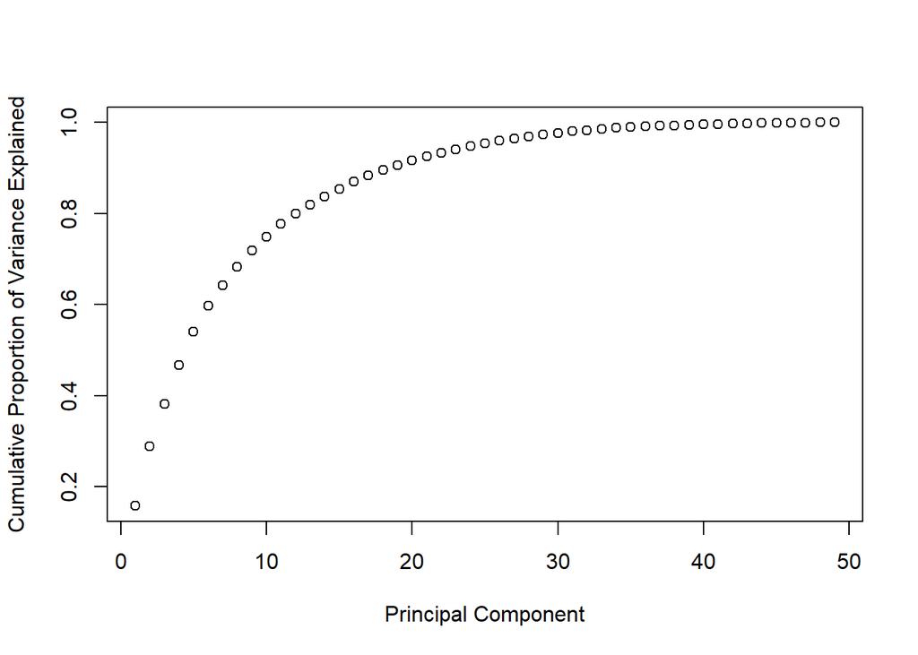

```r
plot(cumsum(prCom2_var_ex),xlab="Principal Component",
     ylab="Cumulative Proportion of Variance Explained")
```

```r
train2.pr<-data.frame(classe=train2$classe,prComp2$x)
train2.pr.new<-train2.pr[,1:15]
modelfit<-train(classe~.,data=train2.pr.new,method="rf")

modelpred<-predict(modelfit,newdata=train2.pr.new)
confusionMatrix(modelpred,train2.pr.new$classe)
```

```
## Confusion Matrix and Statistics
##
##           Reference
## Prediction    A    B    C    D    E
##          A 5580    0    0    0    0
##          B    0 3797    0    0    0
##          C    0    0 3422    0    0
##          D    0    0    0 3216    0
##          E    0    0    0    0 3607
##
## Overall Statistics
##
##                Accuracy : 1
##                  95% CI : (0.9998, 1)
##     No Information Rate : 0.2844
##     P-Value [Acc > NIR] : < 2.2e-16
##
##                   Kappa : 1
##
##  Mcnemar's Test P-Value : NA
##
## Statistics by Class:
##
##                      Class: A Class: B Class: C Class: D Class: E
## Sensitivity            1.0000   1.0000   1.0000   1.0000   1.0000
## Specificity            1.0000   1.0000   1.0000   1.0000   1.0000
## Pos Pred Value         1.0000   1.0000   1.0000   1.0000   1.0000
## Neg Pred Value         1.0000   1.0000   1.0000   1.0000   1.0000
## Prevalence             0.2844   0.1935   0.1744   0.1639   0.1838
## Detection Rate         0.2844   0.1935   0.1744   0.1639   0.1838
## Detection Prevalence   0.2844   0.1935   0.1744   0.1639   0.1838
## Balanced Accuracy      1.0000   1.0000   1.0000   1.0000   1.0000
```

We can see the model appears to show good prediction on the training data

We test the model but first we need to get the testing set data in same format as the training data. The result will be used for the final project quiz.

```r
test.pr<-predict(prComp2, newdata = test2)
test.pr <- as.data.frame(test.pr)
test.pr.2 <- test.pr[,1:15]
pred.test2 <- predict(modelfit, test.pr.2)


pred.test2
```

```
##  [1] B A B A A E D B A A B C B A E E A B B B
## Levels: A B C D E
```